# Assessment 1: Project proposal

Yuyao Chen

2026-11-07

### 1. Research question

This report examines the share of new car sales for battery-electric vehicles (BEVs) and plug-in hybrid electric vehicles (PHEVs) across selected countries from 2015 to 2025, using data from Our World in Data. The analysis aims to identify differences in electric vehicle adoption and explore how sales shares have changed over time. The report focuses on the following questions:

- How did the shares of new cars sold as battery-electric and plug-in hybrids vehicles compare across selected countries or regions between 2015 and 2025?

### 2. Data set introduction

This report uses annual shares of new car sales that are battery-electric or plug-in hybrid vehicles from [Our World in Data](https://ourworldindata.org/grapher/share-car-sales-battery-plugin), which originally sourced from International Energy Agency data. The data set contains observations by country or region from 2010 to 2025.

The dataset contains five variables as shown in Table 1. The variables `phev_share_car_sales` and `bev_share_car_sales` measure the percentage of new car sales accounted for by plug-in hybrid and battery-electric vehicles. These values represent shares of new car sales, not the share of all cars on the road.

Table 1. Structure of the dataset

| Variable | Description | Variable type | Observations | Missing values |
| --- | --- | --- | --- | --- |
| Entity | Entity (country or region) | character | 817 | 0 |
| Code | Geographic county or regional code | character | 817 | 12 |
| Year | Year of observation | numeric | 817 | 0 |
| phev_share_car_sales | Share of new car sold that are plug-in hybrid | numeric | 817 | 108 |
| bev_share_car_sales | Share of new car sold that are battery-electric | numeric | 817 | 8 |

### 3. Data set description

The full data set contains **817 observations** and **5 variables**.

**Figure 1. Screenshot of R code for data description**

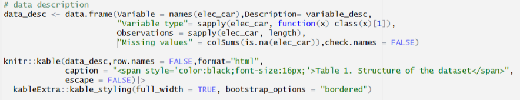

The first two rows of data, with their variable names and data types, are displayed below using `str()`:

```
## tibble [2 × 5] (S3: tbl_df/tbl/data.frame)
##  $ Entity              : chr [1:2] "Australia" "Australia"
##  $ Code                : chr [1:2] "AUS" "AUS"
##  $ Year                : num [1:2] 2011 2012
##  $ phev_share_car_sales: num [1:2] NA 0.00928
##  $ bev_share_car_sales : num [1:2] 0.0061 0.0197
```

Although the dataset cover 2010 and 2025, the analysis focuses on the period from 2015 to 2025. The earlier years were excluded as electric vehicle adoption was still at an early stage in many countries before 2015.

### 4. Data summary

Table 2. Mean and maximum shares of new car sales in selected countries and regions, 2015–2025

| Entity | mean_bev_percentage | max_bev_percentage | mean_phev_percentage | max_phev_percentage |
| --- | --- | --- | --- | --- |
| Norway | 53.7 | 95.4 | 12.1 | 22.1 |
| China | 12.4 | 32.7 | 6.2 | 20.8 |
| United Kingdom | 8.7 | 23.5 | 4.6 | 11.5 |
| Germany | 8.4 | 19.2 | 5.5 | 13.4 |
| European Union (27) | 7.0 | 17.7 | 4.6 | 9.3 |
| World | 6.2 | 16.5 | 3.0 | 8.5 |
| Australia | 3.6 | 11.3 | 0.9 | 3.7 |
| United States | 3.6 | 7.9 | 1.1 | 2.2 |
| Japan | 0.9 | 2.2 | 0.7 | 1.3 |

Among these locations, **Norway** has the **highest mean** battery-electric sales share at **53.7**% between 2015 and 2025. The differences in average battery-electric and plug-in hybrid car sales shares across the selected countries and regions indicate varying pattern of vehicle adoption.

To further examine these differences over time, Table 3 compares battery-electric vehicle sales shares in 2015 and 2025 across the nine selected geographical entities, it shows that Norway recorded the largest increase of 78.6%, followed by China (31.9%), while Japan experienced the smallest increase (1.6%), highlighting substantial differences in the pace of electric vehicle adoption across markets over the decade.

Table 3. Change in battery-electric sales share

| Country/Region | 2015 (%) | 2025 (%) | Change (%) |
| --- | --- | --- | --- |
| Norway | 16.9 | 95.4 | 78.6 |
| China | 0.8 | 32.7 | 31.9 |
| United Kingdom | 0.4 | 23.5 | 23.1 |
| Germany | 0.4 | 19.2 | 18.8 |
| European Union (27) | 0.4 | 17.7 | 17.3 |
| World | 0.4 | 16.5 | 16.1 |
| Australia | 0.1 | 11.3 | 11.2 |
| United States | 0.4 | 7.8 | 7.4 |
| Japan | 0.2 | 1.8 | 1.6 |

### 5. Visualisations

To examine differences in electric vehicle adoption, Figure 2 illustrates the trends in battery-electric and plug-in hybrid vehicle sales shares across nine selected countries and regions from 2015 to 2025.

**Figure 2. Battery-electric and plug-in hybrid new car sales shares across nine selected countries and regions, 2015–2025**

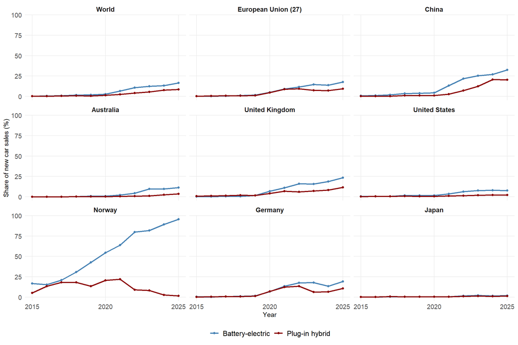

- *Battery-electric vehicle sales shares increased substantially between 2015 and 2025 across most selected countries and regions, with Norway showing the strongest growth, reaching 95.4% in 2025, followed by China at 32.7%.*
- *Battery-electric vehicles generally had higher sales shares than plug-in hybrids, particularly in recent years, while Japan and the United States showed relatively low adoption rates compared with Norway and China.*

To further compare electric vehicle adoption across markets, Figure 3 presents the new car sales with battery-electric and plug-in hybrid vehicle types across nine selected countries and regions in 2025. The stacked bar chart presents the differences in their adoption patterns across markets.

**Figure 3. Share of new cars sold with battery-electric and plug-in hybrid vehicles in 2025**

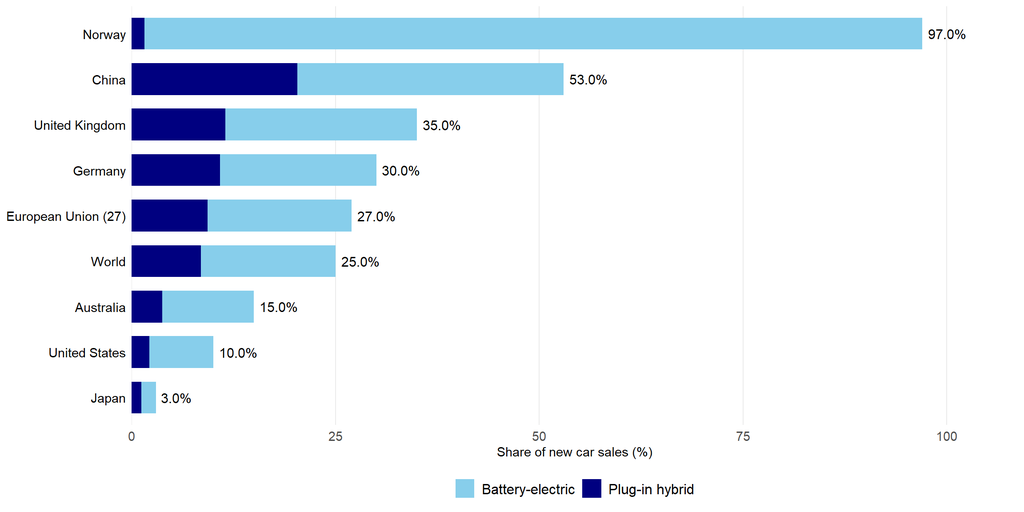

### 6. Conclusion

The analysis finds substantial differences in electric vehicle adoption across the nine selected countries and regions between 2015 and 2025. **Battery-electric** vehicle sales shares increased across most markets, with **Norway** demonstrating the strongest growth and reaching to 95% of new car sales in 2025. China also experienced significant growth, while Japan and the United States recorded comparatively lower electric vehicle sales shares. Plug-in hybrid adoption remained relatively modest in most markets, with Norway showing a declining trend in recent years. The additional bar chart highlights differences in the composition of electric vehicle sales in 2025, while the comparison table demonstrates the varying pace of battery-electric adoption over the decade.

Overall, the findings suggest that battery-electric vehicles have become increasingly important in the global automobile market, although adoption levels and growth patterns vary considerably across countries and regions. These differences highlight the uneven transition towards electric mobility and the increasing dominance of battery-electric vehicles over plug-in hybrids.

### Reference

Our world in data. (2025). *Share of new cars sold that are battery-electric and plug-in hybrid.* https://ourworldindata.org/grapher/share-car-sales-battery-plugin.

RACV. (2026, June 12). *Hybrid vs plug-in hybrid vs mild hybrid vs electric vehicle: what’s the difference?* https://www.racv.com.au/royalauto/transport/electric-vehicles/hybrid-vs-phev-vs-ev-difference.html.

Wickham, H. & Grolemund, G. (2017). *R for Data Science. Chapter 27: R Markdown.* https://r4ds.had.co.nz/r-markdown.html.